# 貸出先別貸出金

アセット･マネジメント･コンサルティング株式会社 http://am-consulting.co.jp

```
## Title : 貸出先別貸出金 総貸出 残高 銀行勘定、信託勘定、海外店勘定の合計(単位:億円) 国内銀行 2016年6月末および4~6月中
## Raw Data Source : 日本銀行
## Author : アセット･マネジメント･コンサルティング株式会社 http://am-consulting.co.jp
## 作成日 : 2016-08-12 14:37:19
## 特記 : 複数のワードで検索する際は半角スペースで区切ってください
## 特記 : 表中、-9999はNAを意味します
```

**貸出先別貸出金 総貸出 残高 銀行勘定、信託勘定、海外店勘定の合計(単位:億円) 国内銀行 2016年6月末および4~6月中**

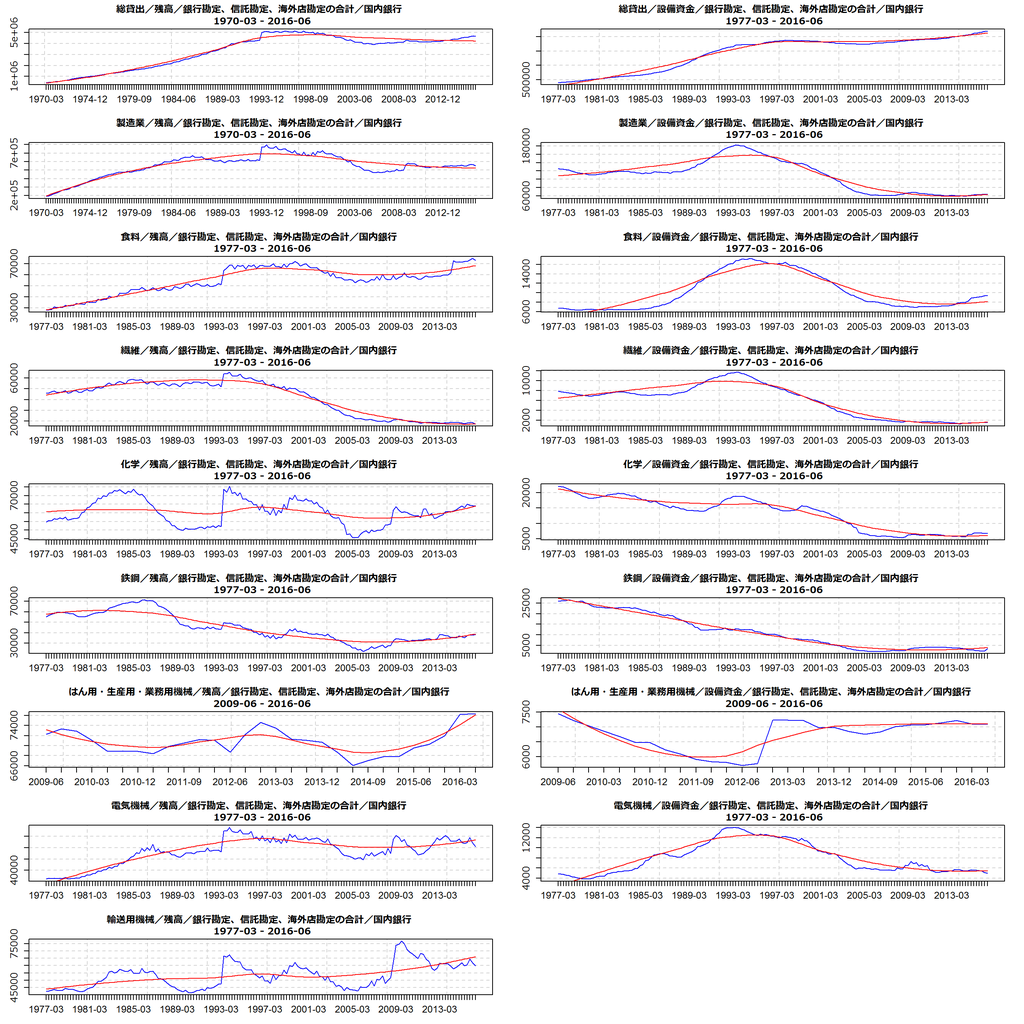

**貸出先別貸出金 総貸出 残高 銀行勘定、信託勘定、海外店勘定の合計(単位:億円) 国内銀行 2016年6月末および4~6月中**

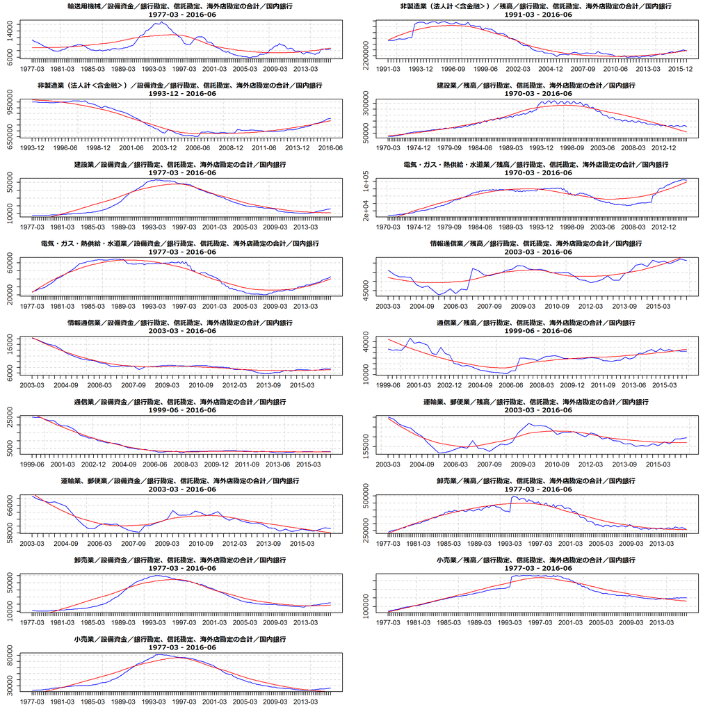

**貸出先別貸出金 総貸出 残高 銀行勘定、信託勘定、海外店勘定の合計(単位:億円) 国内銀行 2016年6月末および4~6月中**

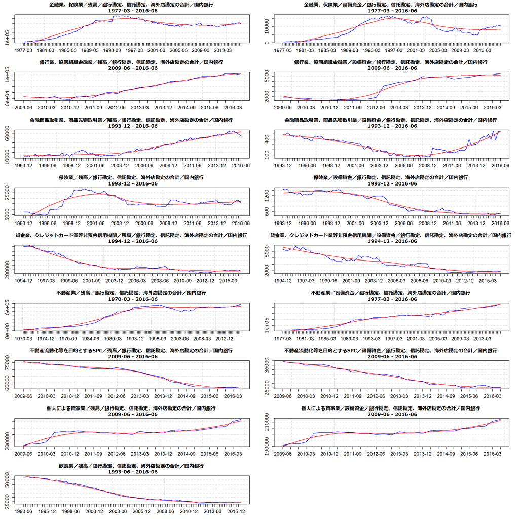

**貸出先別貸出金 総貸出 残高 銀行勘定、信託勘定、海外店勘定の合計(単位:億円) 国内銀行 2016年6月末および4~6月中**

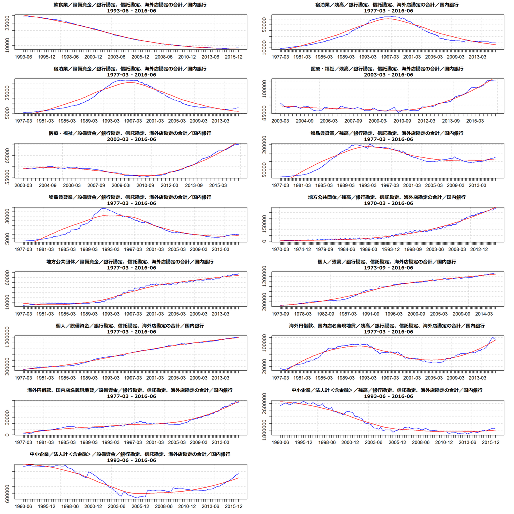

**貸出先別貸出金 総貸出 残高 銀行勘定、信託勘定、海外店勘定の合計(単位:億円) 国内銀行 2016年6月末および4~6月中-前期比(%)**

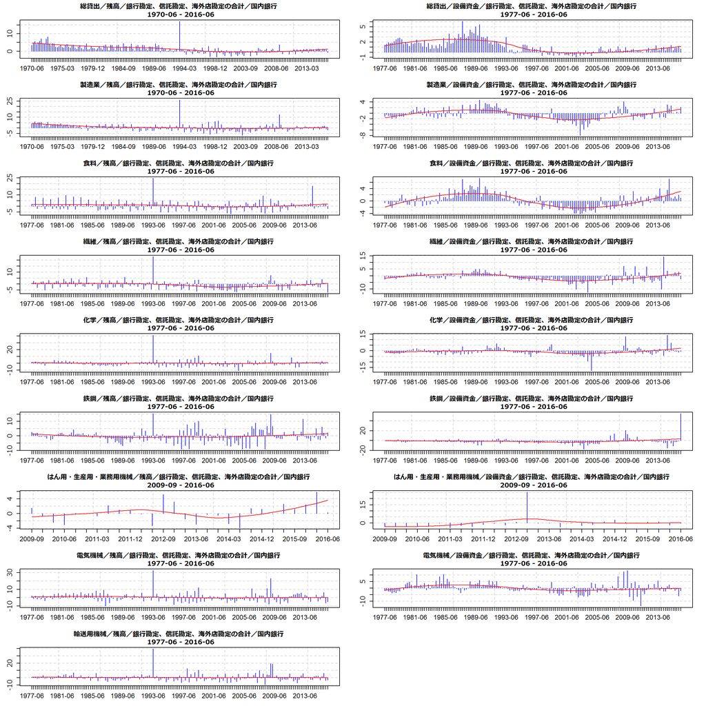

**貸出先別貸出金 総貸出 残高 銀行勘定、信託勘定、海外店勘定の合計(単位:億円) 国内銀行 2016年6月末および4~6月中-前期比(%)**

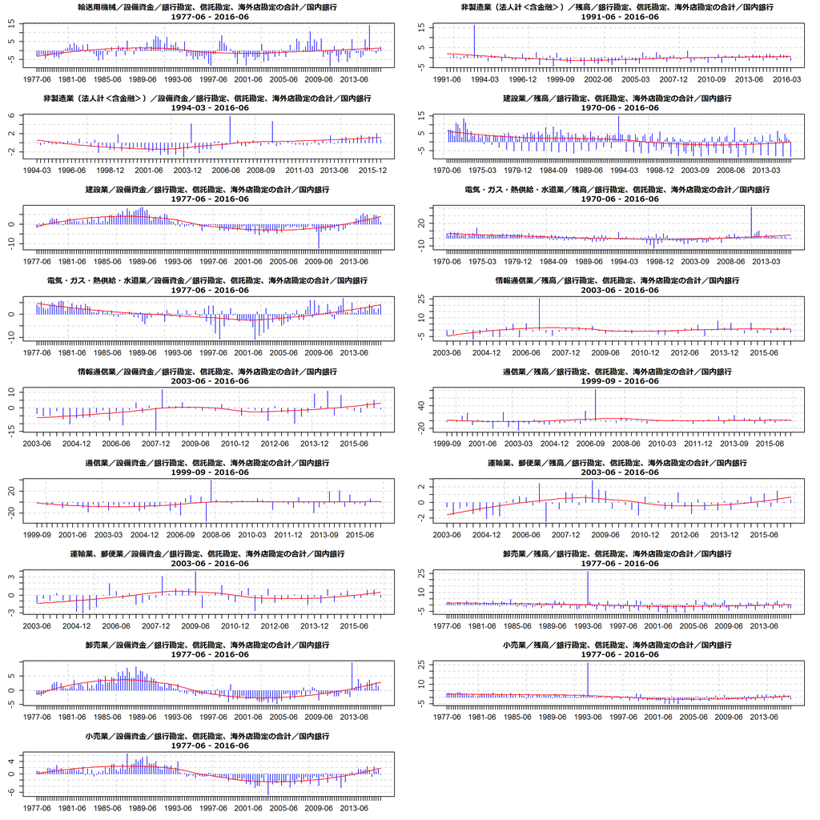

**貸出先別貸出金 総貸出 残高 銀行勘定、信託勘定、海外店勘定の合計(単位:億円) 国内銀行 2016年6月末および4~6月中-前期比(%)**

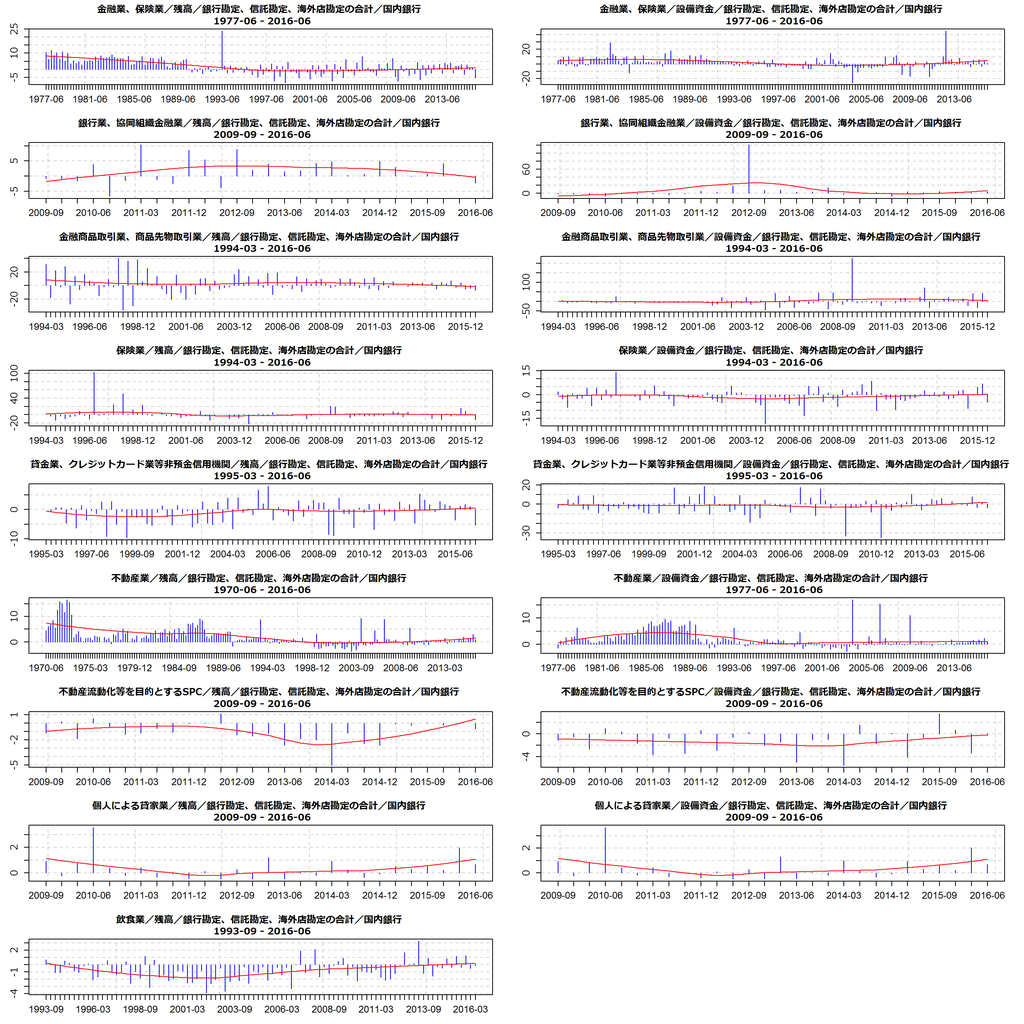

**貸出先別貸出金 総貸出 残高 銀行勘定、信託勘定、海外店勘定の合計(単位:億円) 国内銀行 2016年6月末および4~6月中-前期比(%)**

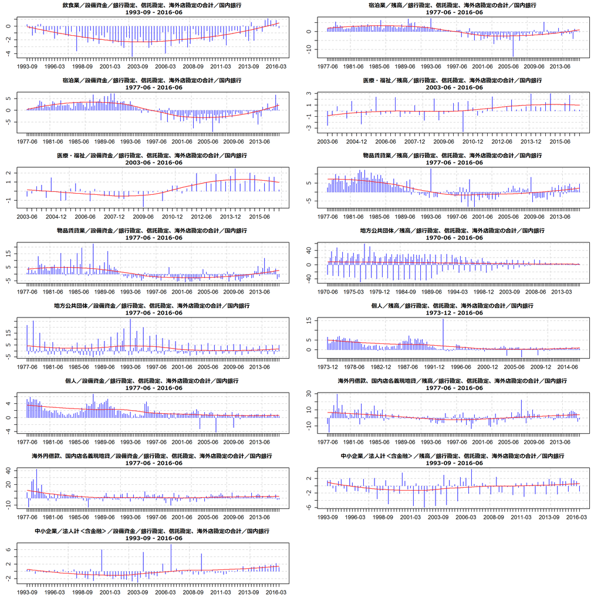